# Supervised Learning Classification Project: AllLife Bank Personal Loan Campaign

#### ITERATION (2) - Visualize the Decision Tree

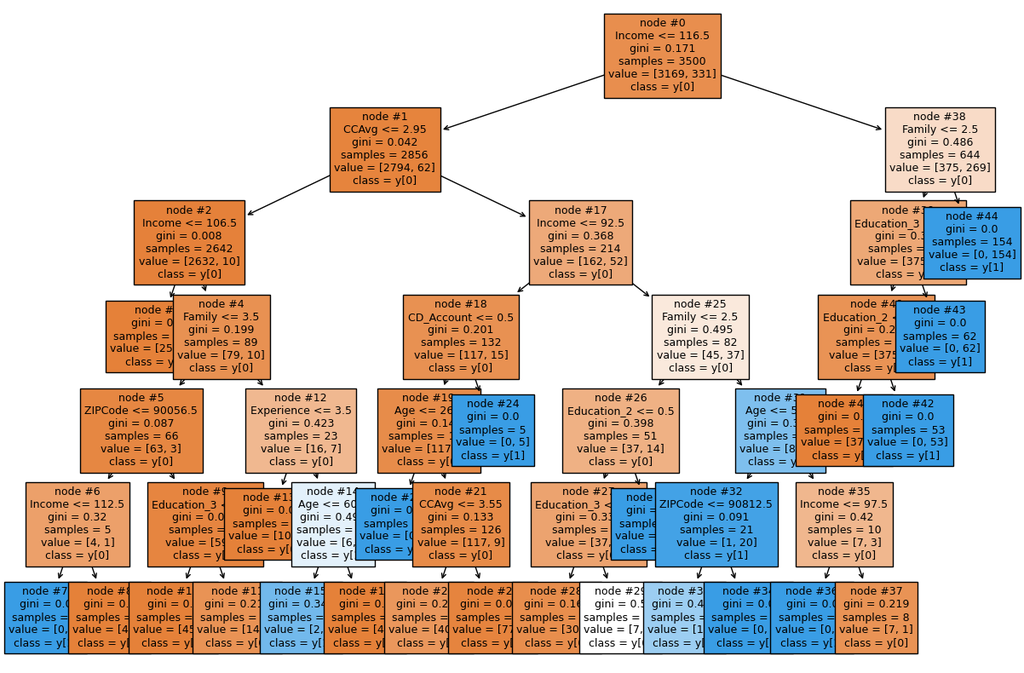

```python
# Visualize the Decision Tree


plt.figure(figsize=(15,10))

tree.plot_tree(dTreeModel1,feature_names=feature_names,filled=True,fontsize=9,node_ids=True,class_names=True)
plt.show()
```

```python
# Printing the rules of a decision tree -

print(tree.export_text(dTreeModel1,feature_names=feature_names,show_weights=True))
```

```
|--- Income <= 116.50
|   |--- CCAvg <= 2.95
|   |   |--- Income <= 106.50
|   |   |   |--- weights: [2553.00, 0.00] class: 0
|   |   |--- Income >  106.50
|   |   |   |--- Family <= 3.50
|   |   |   |   |--- ZIPCode <= 90056.50
|   |   |   |   |   |--- Income <= 112.50
|   |   |   |   |   |   |--- weights: [0.00, 1.00] class: 1
|   |   |   |   |   |--- Income >  112.50
|   |   |   |   |   |   |--- weights: [4.00, 0.00] class: 0
|   |   |   |   |--- ZIPCode >  90056.50
|   |   |   |   |   |--- Education_3 <= 0.50
|   |   |   |   |   |   |--- weights: [45.00, 0.00] class: 0
|   |   |   |   |   |--- Education_3 >  0.50
|   |   |   |   |   |   |--- weights: [14.00, 2.00] class: 0
|   |   |   |--- Family >  3.50
|   |   |   |   |--- Experience <= 3.50
|   |   |   |   |   |--- weights: [10.00, 0.00] class: 0
|   |   |   |   |--- Experience >  3.50
|   |   |   |   |   |--- Age <= 60.00
|   |   |   |   |   |   |--- weights: [2.00, 7.00] class: 1
|   |   |   |   |   |--- Age >  60.00
|   |   |   |   |   |   |--- weights: [4.00, 0.00] class: 0
|   |--- CCAvg >  2.95
|   |   |--- Income <= 92.50
|   |   |   |--- CD_Account <= 0.50
|   |   |   |   |--- Age <= 26.50
|   |   |   |   |   |--- weights: [0.00, 1.00] class: 1
|   |   |   |   |--- Age >  26.50
|   |   |   |   |   |--- CCAvg <= 3.55
|   |   |   |   |   |   |--- weights: [40.00, 7.00] class: 0
|   |   |   |   |   |--- CCAvg >  3.55
|   |   |   |   |   |   |--- weights: [77.00, 2.00] class: 0
|   |   |   |--- CD_Account >  0.50
|   |   |   |   |--- weights: [0.00, 5.00] class: 1
|   |   |--- Income >  92.50
|   |   |   |--- Family <= 2.50
|   |   |   |   |--- Education_2 <= 0.50
|   |   |   |   |   |--- Education_3 <= 0.50
```

[output cut: 12 more lines]

```
|   |   |   |   |   |--- Income <= 97.50
|   |   |   |   |   |   |--- weights: [0.00, 2.00] class: 1
|   |   |   |   |   |--- Income >  97.50
|   |   |   |   |   |   |--- weights: [7.00, 1.00] class: 0
|--- Income >  116.50
|   |--- Family <= 2.50
|   |   |--- Education_3 <= 0.50
|   |   |   |--- Education_2 <= 0.50
|   |   |   |   |--- weights: [375.00, 0.00] class: 0
|   |   |   |--- Education_2 >  0.50
|   |   |   |   |--- weights: [0.00, 53.00] class: 1
|   |   |--- Education_3 >  0.50
|   |   |   |--- weights: [0.00, 62.00] class: 1
|   |--- Family >  2.50
|   |   |--- weights: [0.00, 154.00] class: 1
```

```python
# Printing the importance of features in the tree building (Gini importance)

print (pd.DataFrame(dTreeModel1.feature_importances_, columns = ["IMPORTANCE"], index = X_train.columns).sort_values(by = 'IMPORTANCE', ascending = False))
```

```
                    IMPORTANCE
Income                0.325167
Family                0.263554
Education_2           0.173562
Education_3           0.154615
CCAvg                 0.041956
Age                   0.019286
CD_Account            0.014544
Experience            0.005838
ZIPCode               0.001478
Mortgage              0.000000
Securities_Account    0.000000
Online                0.000000
CreditCard            0.000000
```

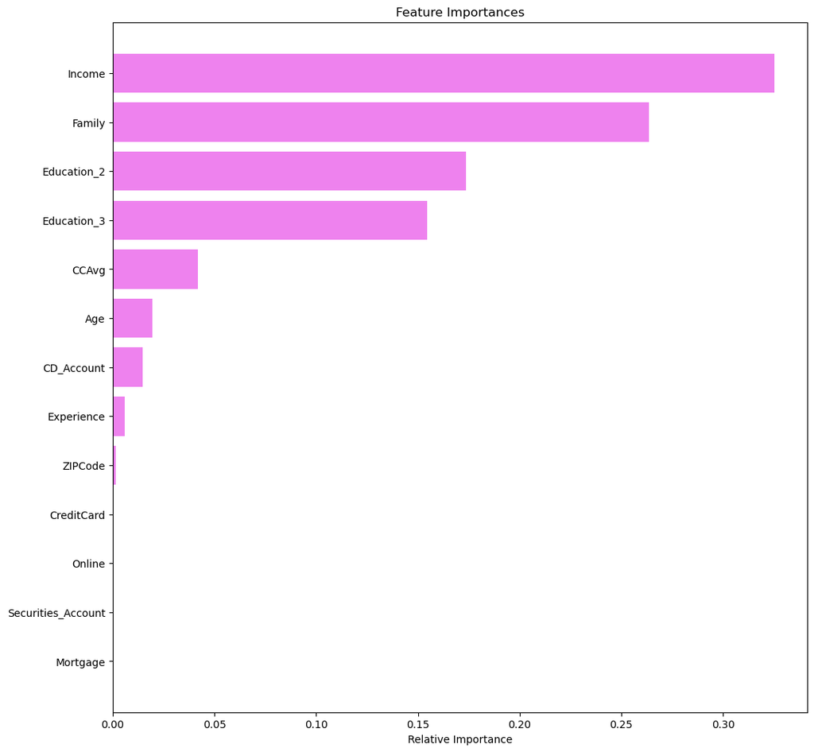

```python
# Drawing the importance graph again


importances = dTreeModel1.feature_importances_
indices = np.argsort(importances)

plt.figure(figsize=(12,12))
plt.title("Feature Importances")
plt.barh(range(len(indices)), importances[indices], color="violet", align="center")
plt.yticks(range(len(indices)), [feature_names[i] for i in indices])
plt.xlabel("Relative Importance")
plt.show()
```

#### ITERATION (2) - Checking performance on testing data

```python
# Accuracy, Recall and Precision on trest set


decision_tree_perf_pre_test = model_performance_classification_sklearn(dTreeModel1, X_test, y_test)
decision_tree_perf_pre_test
```

|  | Accuracy | Recall | Precision | F1 |
| --- | --- | --- | --- | --- |
| 0 | 0.986 | 0.865772 | 0.992308 | 0.924731 |

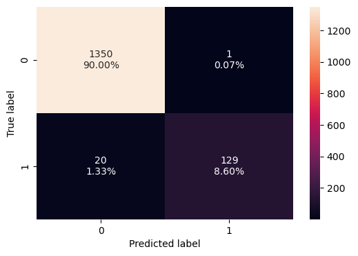

```python
# performance on test data

confusion_matrix_sklearn(dTreeModel1, X_test, y_test)
```

### OBSERVATIONS (Pre - Pruning)

##### Comparing the performance of training and test data with pre-pruning

###### Performance Training

- Accuracy : 0.992857
- Recall : 0.933535
- Precision: 0.990385
- F1 Score : 0.96112

###### Performance Testing

- Accuracy : 0.986
- Recall : 0.865772
- Precision: 0.992308
- F1 Score : 0.924731

#### ITERATION (2) - Cost Complexity Pruning

#### Total impurity of leaves vs effective alphas of pruned tree

```python
clf = DecisionTreeClassifier(random_state=1)
path = clf.cost_complexity_pruning_path(X_train, y_train)
ccp_alphas, impurities = path.ccp_alphas, path.impurities
```

```python
# As alpha increases, more of the tree is pruned, which increases the total impurity of its leaves.

pd.DataFrame(path)
```

|  | ccp_alphas | impurities |
| --- | --- | --- |
| 0 | 0.000000 | 0.000000 |
| 1 | 0.000186 | 0.001114 |
| 2 | 0.000250 | 0.001614 |
| 3 | 0.000267 | 0.002147 |
| 4 | 0.000268 | 0.003221 |
| 5 | 0.000272 | 0.003765 |
| 6 | 0.000276 | 0.004868 |
| 7 | 0.000276 | 0.005420 |
| 8 | 0.000381 | 0.005801 |
| 9 | 0.000381 | 0.006182 |
| 10 | 0.000429 | 0.006611 |
| 11 | 0.000508 | 0.007119 |
| 12 | 0.000625 | 0.007744 |
| 13 | 0.000700 | 0.008444 |
| 14 | 0.000769 | 0.011521 |
| 15 | 0.000771 | 0.012292 |
| 16 | 0.000792 | 0.015460 |
| 17 | 0.000800 | 0.016260 |
| 18 | 0.000940 | 0.017200 |
| 19 | 0.001305 | 0.018505 |
| 20 | 0.001647 | 0.020153 |
| 21 | 0.002333 | 0.022486 |
| 22 | 0.002407 | 0.024893 |
| 23 | 0.003294 | 0.028187 |
| 24 | 0.006473 | 0.034659 |
| 25 | 0.025146 | 0.084951 |
| 26 | 0.039216 | 0.124167 |
| 27 | 0.047088 | 0.171255 |

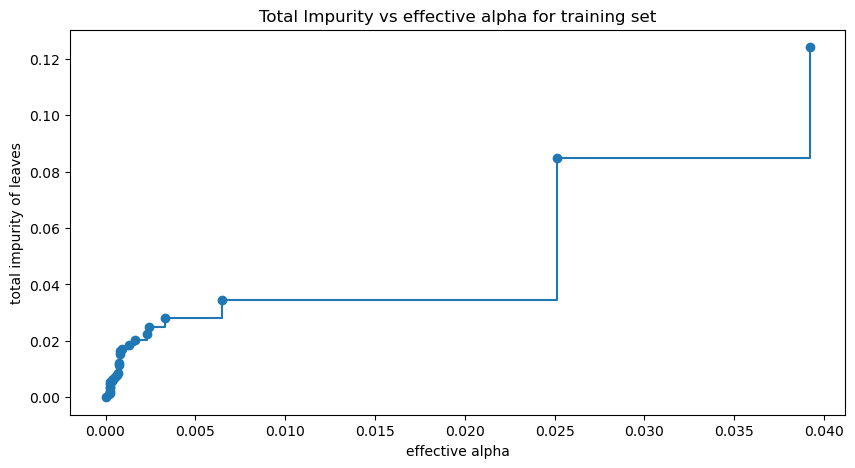

```python
fig, ax = plt.subplots(figsize=(10,5))
ax.plot(ccp_alphas[:-1], impurities[:-1], marker='o', drawstyle="steps-post")
ax.set_xlabel("effective alpha")
ax.set_ylabel("total impurity of leaves")
ax.set_title("Total Impurity vs effective alpha for training set")
plt.show()
```

```python
# Next, we train a decision tree using effective alphas. The last value in ccp_alphas is the alpha value that prunes the whole tree, leaving the tree, clfs[-1], with one node.


clfs = []
for ccp_alpha in ccp_alphas:
    clf = DecisionTreeClassifier(random_state=1, ccp_alpha=ccp_alpha)
    clf.fit(X_train, y_train)     ## Complete the code to fit decision tree on training data
    clfs.append(clf)
print(
    "Number of nodes in the last tree is: {} with ccp_alpha: {}".format(
        clfs[-1].tree_.node_count, ccp_alphas[-1]
    )
)
```

```
Number of nodes in the last tree is: 1 with ccp_alpha: 0.04708834100596766
```

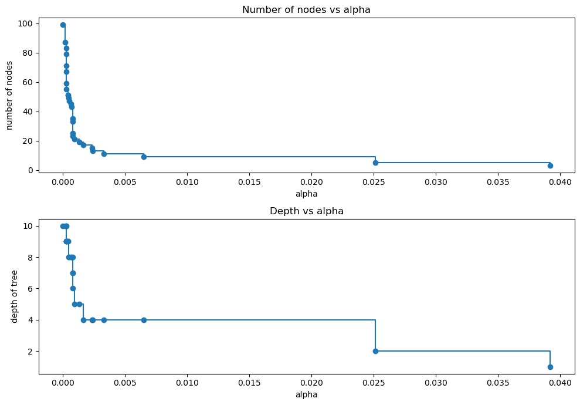

```python
clfs = clfs[:-1]
ccp_alphas = ccp_alphas[:-1]

node_counts = [clf.tree_.node_count for clf in clfs]
depth = [clf.tree_.max_depth for clf in clfs]
fig, ax = plt.subplots(2, 1, figsize=(10, 7))
ax[0].plot(ccp_alphas, node_counts, marker="o", drawstyle="steps-post")
ax[0].set_xlabel("alpha")
ax[0].set_ylabel("number of nodes")
ax[0].set_title("Number of nodes vs alpha")
ax[1].plot(ccp_alphas, depth, marker="o", drawstyle="steps-post")
ax[1].set_xlabel("alpha")
ax[1].set_ylabel("depth of tree")
ax[1].set_title("Depth vs alpha")
fig.tight_layout()
```

#### ITERATION (2) - Recall vs alpha for training and testing sets

```python
recall_train = []
for clf in clfs:
    pred_train = clf.predict(X_train)
    values_train = recall_score(y_train, pred_train)
    recall_train.append(values_train)
```

```python
recall_test = []
for clf in clfs:
    pred_test = clf.predict(X_test)
    values_test = recall_score(y_test, pred_test)
    recall_test.append(values_test)
```

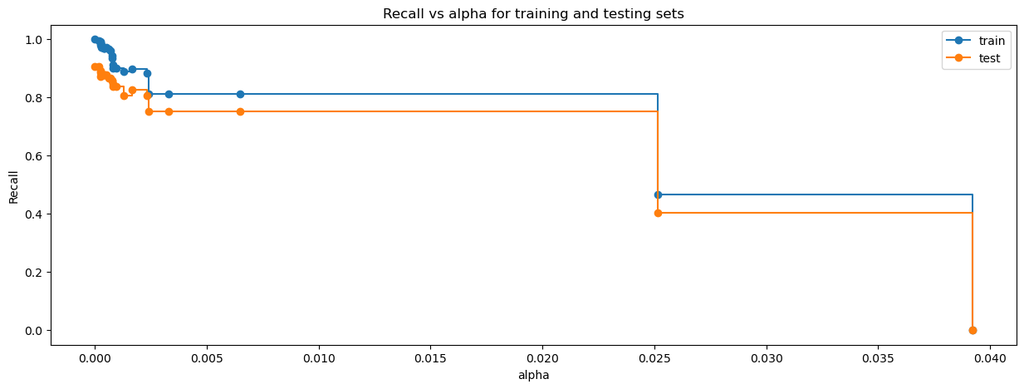

```python
fig, ax = plt.subplots(figsize=(15, 5))
ax.set_xlabel("alpha")
ax.set_ylabel("Recall")
ax.set_title("Recall vs alpha for training and testing sets")
ax.plot(ccp_alphas, recall_train, marker="o", label="train", drawstyle="steps-post")
ax.plot(ccp_alphas, recall_test, marker="o", label="test", drawstyle="steps-post")
ax.legend()
plt.show()
```

```python
index_best_model = np.argmax(recall_test)
best_model = clfs[index_best_model]
print(best_model)
```

```
DecisionTreeClassifier(random_state=1)
```

### ITERATION 3

### Reviewing the Model Performance by Post-Pruning

#### Iteration (3) - Checking performance on training data

```python
dTreeModel2 = DecisionTreeClassifier(
    ccp_alpha=ccp_alpha, class_weight={0: 0.15, 1: 0.85}, random_state=1         ## Complete the code by adding the correct ccp_alpha value
)
dTreeModel2.fit(X_train, y_train)
```

```
DecisionTreeClassifier(ccp_alpha=0.04708834100596766,
                       class_weight={0: 0.15, 1: 0.85}, random_state=1)
```

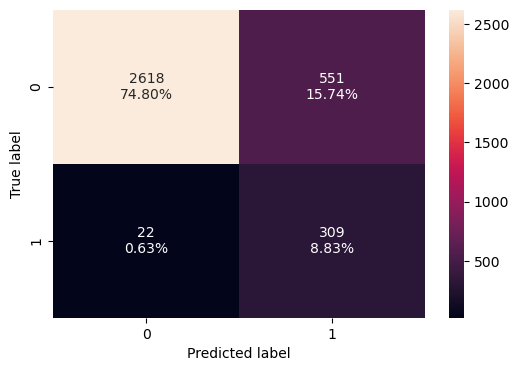

```python
confusion_matrix_sklearn(dTreeModel2, X_train, y_train)
```

```python
# Complete the code to get the model performance on test data
decision_tree_perf_post_train = model_performance_classification_sklearn(dTreeModel2, X_train, y_train)
decision_tree_perf_post_train
```

|  | Accuracy | Recall | Precision | F1 |
| --- | --- | --- | --- | --- |
| 0 | 0.836286 | 0.933535 | 0.359302 | 0.518892 |

#### Iteration (3) - Visualizing the Decision Tree

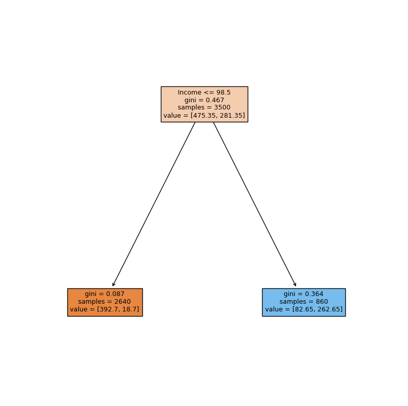

```python
plt.figure(figsize=(10, 10))
out = tree.plot_tree(
    dTreeModel2,
    feature_names=feature_names,
    filled=True,
    fontsize=9,
    node_ids=False,
    class_names=None,
)
# below code will add arrows to the decision tree split if they are missing
for o in out:
    arrow = o.arrow_patch
    if arrow is not None:
        arrow.set_edgecolor("black")
        arrow.set_linewidth(1)
plt.show()
```

```python
print(tree.export_text(dTreeModel2, feature_names=feature_names, show_weights=True))
```

```
|--- Income <= 98.50
|   |--- weights: [392.70, 18.70] class: 0
|--- Income >  98.50
|   |--- weights: [82.65, 262.65] class: 1
```

```python
print(
    pd.DataFrame(
        dTreeModel2.feature_importances_, columns=["Imp"], index=X_train.columns
    ).sort_values(by="Imp", ascending=False)
)
```

```
                    Imp
Income              1.0
Age                 0.0
Experience          0.0
ZIPCode             0.0
Family              0.0
CCAvg               0.0
Mortgage            0.0
Securities_Account  0.0
CD_Account          0.0
Online              0.0
CreditCard          0.0
Education_2         0.0
Education_3         0.0
```

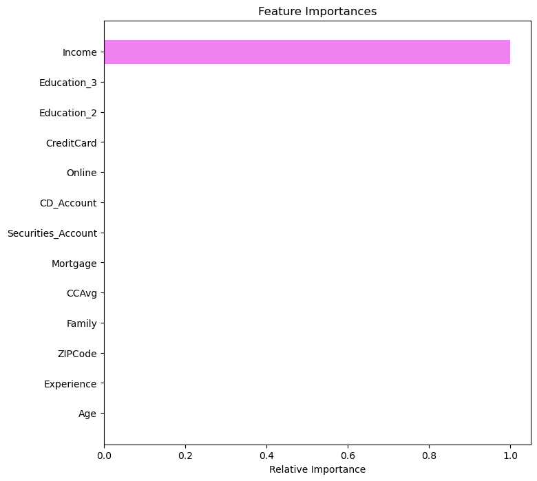

```python
importances = dTreeModel2.feature_importances_
indices = np.argsort(importances)

plt.figure(figsize=(8, 8))
plt.title("Feature Importances")
plt.barh(range(len(indices)), importances[indices], color="violet", align="center")
plt.yticks(range(len(indices)), [feature_names[i] for i in indices])
plt.xlabel("Relative Importance")
plt.show()
```

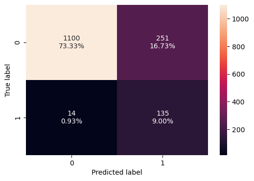

```python
confusion_matrix_sklearn(dTreeModel2, X_test, y_test)
```

```python
decision_tree_perf_post_test = model_performance_classification_sklearn(dTreeModel2, X_test, y_test)
decision_tree_perf_post_test
```

|  | Accuracy | Recall | Precision | F1 |
| --- | --- | --- | --- | --- |
| 0 | 0.823333 | 0.90604 | 0.349741 | 0.504673 |

### OBSERVATIONS (Post - Pruning)

##### Comparing the performance of training and test data with post-pruning

###### Performance Training

- Accuracy : 0.836286
- Recall : 0.933535
- Precision: 0.359302
- F1 Score : 0.518892

###### Performance Testing

- Accuracy : 0.823333
- Recall : 0.90604
- Precision: 0.349741
- F1 Score : 0.504673

## Model Comparison and Final Model Selection

```python
# training performance comparison

models_train_comp_df = pd.concat(
    [decision_tree_perf_train.T, decision_tree_perf_pre_train.T,decision_tree_perf_post_train.T], axis=1,
)
models_train_comp_df.columns = ["Decision Tree sklearn",
                                "Decision Tree (Pre-Pruning)",
                                "Decision Tree (Post-Pruning)"]

print("Training performance comparison:")

models_train_comp_df
```

```
Training performance comparison:
```

|  | Decision Tree sklearn | Decision Tree (Pre-Pruning) | Decision Tree (Post-Pruning) |
| --- | --- | --- | --- |
| Accuracy | 1.0 | 0.992857 | 0.836286 |
| Recall | 1.0 | 0.933535 | 0.933535 |
| Precision | 1.0 | 0.990385 | 0.359302 |
| F1 | 1.0 | 0.961120 | 0.518892 |

```python
# testing performance comparison

models_test_comp_df = pd.concat(
    [decision_tree_perf_test.T, decision_tree_perf_pre_test.T,decision_tree_perf_post_test.T], axis=1,
)
models_test_comp_df.columns = ["Decision Tree sklearn",
                               "Decision Tree (Pre-Pruning)",
                               "Decision Tree (Post-Pruning)"]

print("Testing performance comparison:")

models_test_comp_df
```

```
Testing performance comparison:
```

|  | Decision Tree sklearn | Decision Tree (Pre-Pruning) | Decision Tree (Post-Pruning) |
| --- | --- | --- | --- |
| Accuracy | 0.986000 | 0.986000 | 0.823333 |
| Recall | 0.906040 | 0.865772 | 0.906040 |
| Precision | 0.950704 | 0.992308 | 0.349741 |
| F1 | 0.927835 | 0.924731 | 0.504673 |

## Actionable Insights and Business Recommendations

We can recommend the following to the bank:

- The Income is the major factor to be considered for targeting customers
- Other factors apart from income are Family, Education and CCAvg to be considered for identifying high valued customers for a personal loan.
- Customers with more family members tend to take a personal loan
- Customers with high income range have a higher possibility and apetite for a personal loan
- Similarly, customers with better education are also possible prospective customers for a loan.
- There are prospective customers in some of the zip-codes as well where they have taken personal loans. This will also be one of the factors but should also be considered post the Income, Family, and education evaluations.